# 12018_UAS copy 3

## Dimention Reduction & Binary Classification in Employee Attrition Prediction

## Dataset Information

Uncover the factors that lead to employee attrition and explore important questions such as ‘show me a breakdown of distance from home by job role and attrition’ or ‘compare average monthly income by education and attrition’. This is a fictional data set created by IBM data scientists.

## Attribute Information

Education: 1 'Below College', 2 'College', 3 'Bachelor', 4 'Master', 5 'Doctor'

EnvironmentSatisfaction: 1 'Low', 2 'Medium', 3 'High', 4 'Very High'

JobInvolvement: 1 'Low', 2 'Medium', 3 'High', 4 'Very High'

JobSatisfaction: 1 'Low', 2 'Medium', 3 'High', 4 'Very High'

PerformanceRating: 1 'Low', 2 'Good', 3 'Excellent', 4 'Outstanding'

RelationshipSatisfaction: 1 'Low', 2 'Medium', 3 'High', 4 'Very High'

WorkLifeBalance: 1 'Bad', 2 'Good', 3 'Better', 4 'Best'

## Goal

Here, lets create classification model which feature were created from PCA only. The reason for choosing this approach were:

1. Dataset contains lots of feature.
2. Dataset contain several strongly correlated features.
3. Tackle the curse of dimentionality, since fewer the dimentions involved in creating classification, the smaller the resource used, also lead to quicker time to train the model.

There were also lots of binary classification algorithm used even thou the author weren't completely lookup for the underlying assumption for each model, therefore this extra step just an addition for reference of python capabilities in creating model selection with looping.

Source: https://www.kaggle.com/datasets/pavansubhasht/ibm-hr-analytics-attrition-dataset

```python
import mlflow
print(mlflow.__version__)

import pandas as pd
from factor_analyzer import FactorAnalyzer
import matplotlib.pyplot as plt
import numpy as np
```

```
1.29.0
```

## Import and Clean Dataset </h1>

```python
attr_raw = pd.read_csv("D:/Kuliah/semester_1/Statistika dan Analisis Multivariat/UAS/WA_Fn-UseC_-HR-Employee-Attrition.csv", sep=",")

attr_raw.head(5)
```

|  | Age | Attrition | BusinessTravel | DailyRate | Department | DistanceFromHome | Education | EducationField | EmployeeCount | EmployeeNumber | ... | RelationshipSatisfaction | StandardHours | StockOptionLevel | TotalWorkingYears | TrainingTimesLastYear | WorkLifeBalance | YearsAtCompany | YearsInCurrentRole | YearsSinceLastPromotion | YearsWithCurrManager |
| --- | --- | --- | --- | --- | --- | --- | --- | --- | --- | --- | --- | --- | --- | --- | --- | --- | --- | --- | --- | --- | --- |
| 0 | 41 | Yes | Travel_Rarely | 1102 | Sales | 1 | 2 | Life Sciences | 1 | 1 | ... | 1 | 80 | 0 | 8 | 0 | 1 | 6 | 4 | 0 | 5 |
| 1 | 49 | No | Travel_Frequently | 279 | Research & Development | 8 | 1 | Life Sciences | 1 | 2 | ... | 4 | 80 | 1 | 10 | 3 | 3 | 10 | 7 | 1 | 7 |
| 2 | 37 | Yes | Travel_Rarely | 1373 | Research & Development | 2 | 2 | Other | 1 | 4 | ... | 2 | 80 | 0 | 7 | 3 | 3 | 0 | 0 | 0 | 0 |
| 3 | 33 | No | Travel_Frequently | 1392 | Research & Development | 3 | 4 | Life Sciences | 1 | 5 | ... | 3 | 80 | 0 | 8 | 3 | 3 | 8 | 7 | 3 | 0 |
| 4 | 27 | No | Travel_Rarely | 591 | Research & Development | 2 | 1 | Medical | 1 | 7 | ... | 4 | 80 | 1 | 6 | 3 | 3 | 2 | 2 | 2 | 2 |

5 rows × 35 columns

```python
attr_raw.dtypes
```

```
Age                          int64
Attrition                   object
BusinessTravel              object
DailyRate                    int64
Department                  object
DistanceFromHome             int64
Education                    int64
EducationField              object
EmployeeCount                int64
EmployeeNumber               int64
EnvironmentSatisfaction      int64
Gender                      object
HourlyRate                   int64
JobInvolvement               int64
JobLevel                     int64
JobRole                     object
JobSatisfaction              int64
MaritalStatus               object
MonthlyIncome                int64
MonthlyRate                  int64
NumCompaniesWorked           int64
Over18                      object
OverTime                    object
PercentSalaryHike            int64
PerformanceRating            int64
RelationshipSatisfaction     int64
StandardHours                int64
StockOptionLevel             int64
TotalWorkingYears            int64
TrainingTimesLastYear        int64
WorkLifeBalance              int64
YearsAtCompany               int64
YearsInCurrentRole           int64
YearsSinceLastPromotion      int64
YearsWithCurrManager         int64
dtype: object
```

```python
attr_raw.isna().any()
```

```
Age                         False
Attrition                   False
BusinessTravel              False
DailyRate                   False
Department                  False
DistanceFromHome            False
Education                   False
EducationField              False
EmployeeCount               False
EmployeeNumber              False
EnvironmentSatisfaction     False
Gender                      False
HourlyRate                  False
JobInvolvement              False
JobLevel                    False
JobRole                     False
JobSatisfaction             False
MaritalStatus               False
MonthlyIncome               False
MonthlyRate                 False
NumCompaniesWorked          False
Over18                      False
OverTime                    False
PercentSalaryHike           False
PerformanceRating           False
RelationshipSatisfaction    False
StandardHours               False
StockOptionLevel            False
TotalWorkingYears           False
TrainingTimesLastYear       False
WorkLifeBalance             False
YearsAtCompany              False
YearsInCurrentRole          False
YearsSinceLastPromotion     False
YearsWithCurrManager        False
dtype: bool
```

```python
attr_raw['Attrition'].value_counts()
```

```
No     1233
Yes     237
Name: Attrition, dtype: int64
```

Here, I exclude the 0 values in TotalWorkingYears, YearsAtCompany, YearsInCurrentRole, YearsWithCurrManager, and YearsSinceLastPromotion, therefore eliminating relative newcomer in the analysis since it may cause hurdles in the data preprocessing step, which is in process of eliminating outlier since the use of log transformation resulting in infinity and root transformation creating large gap between.

```python
attr_raw = attr_raw[(attr_raw.TotalWorkingYears != 0)&(attr_raw.YearsAtCompany != 0)&(attr_raw.YearsInCurrentRole != 0)&(attr_raw.YearsWithCurrManager != 0)&(attr_raw.YearsSinceLastPromotion != 0)]
```

```python
attr_raw['Attrition'].value_counts()
```

```
No     702
Yes    104
Name: Attrition, dtype: int64
```

```python
from sklearn.utils import resample

# Separate majority and minority class
attr_majority = attr_raw[attr_raw['Attrition']=="No"]
attr_minority = attr_raw[attr_raw['Attrition']=="Yes"]

# Upsample majority class
attr_minority_up = resample(attr_minority,
                                replace = True,
                                n_samples=702,
                                random_state=100)

# Combine majority and minority class
attr_sampled = pd.concat([attr_minority_up, attr_majority])

attr_sampled["Attrition"].value_counts()
```

```
Yes    702
No     702
Name: Attrition, dtype: int64
```

```python
attr_sampled.info()
```

```
<class 'pandas.core.frame.DataFrame'>
Int64Index: 1404 entries, 132 to 1469
Data columns (total 35 columns):
 #   Column                    Non-Null Count  Dtype
---  ------                    --------------  -----
 0   Age                       1404 non-null   int64
 1   Attrition                 1404 non-null   object
 2   BusinessTravel            1404 non-null   object
 3   DailyRate                 1404 non-null   int64
 4   Department                1404 non-null   object
 5   DistanceFromHome          1404 non-null   int64
 6   Education                 1404 non-null   int64
 7   EducationField            1404 non-null   object
 8   EmployeeCount             1404 non-null   int64
 9   EmployeeNumber            1404 non-null   int64
```

[output cut: 27 more lines]

```python
attr_cat = attr_sampled[['Attrition','BusinessTravel','Department','Education','EducationField','EmployeeCount','EmployeeNumber','EnvironmentSatisfaction','Gender','JobLevel','JobRole','JobSatisfaction','MaritalStatus','Over18','OverTime','PerformanceRating','StandardHours','WorkLifeBalance']]

attr_cat.shape
```

```
(1404, 18)
```

```python
attr_metrices = attr_sampled

# Select metric variables
attr_metrices.drop(['Attrition','BusinessTravel','Department','Education','EducationField','EmployeeCount','EmployeeNumber','EnvironmentSatisfaction','Gender','JobLevel','JobRole','JobSatisfaction','MaritalStatus','Over18','OverTime','PerformanceRating','StandardHours','WorkLifeBalance'], axis=1, inplace=True)
```

```python
attr_metrices.info()
```

```
<class 'pandas.core.frame.DataFrame'>
Int64Index: 1404 entries, 132 to 1469
Data columns (total 17 columns):
 #   Column                    Non-Null Count  Dtype
---  ------                    --------------  -----
 0   Age                       1404 non-null   int64
 1   DailyRate                 1404 non-null   int64
 2   DistanceFromHome          1404 non-null   int64
 3   HourlyRate                1404 non-null   int64
 4   JobInvolvement            1404 non-null   int64
 5   MonthlyIncome             1404 non-null   int64
 6   MonthlyRate               1404 non-null   int64
 7   NumCompaniesWorked        1404 non-null   int64
 8   PercentSalaryHike         1404 non-null   int64
 9   RelationshipSatisfaction  1404 non-null   int64
 10  StockOptionLevel          1404 non-null   int64
 11  TotalWorkingYears         1404 non-null   int64
 12  TrainingTimesLastYear     1404 non-null   int64
 13  YearsAtCompany            1404 non-null   int64
 14  YearsInCurrentRole        1404 non-null   int64
 15  YearsSinceLastPromotion   1404 non-null   int64
 16  YearsWithCurrManager      1404 non-null   int64
dtypes: int64(17)
memory usage: 197.4 KB
```

```python
attr_metrices.head()
```

|  | Age | DailyRate | DistanceFromHome | HourlyRate | JobInvolvement | MonthlyIncome | MonthlyRate | NumCompaniesWorked | PercentSalaryHike | RelationshipSatisfaction | StockOptionLevel | TotalWorkingYears | TrainingTimesLastYear | YearsAtCompany | YearsInCurrentRole | YearsSinceLastPromotion | YearsWithCurrManager |
| --- | --- | --- | --- | --- | --- | --- | --- | --- | --- | --- | --- | --- | --- | --- | --- | --- | --- |
| 132 | 31 | 542 | 20 | 71 | 1 | 4559 | 24788 | 3 | 11 | 3 | 1 | 4 | 2 | 2 | 2 | 2 | 2 |
| 436 | 33 | 587 | 10 | 38 | 1 | 3408 | 6705 | 7 | 13 | 1 | 3 | 8 | 2 | 4 | 3 | 1 | 3 |
| 947 | 52 | 1030 | 5 | 64 | 3 | 8446 | 21534 | 9 | 19 | 3 | 0 | 10 | 2 | 8 | 7 | 7 | 7 |
| 1444 | 56 | 310 | 7 | 72 | 3 | 2339 | 3666 | 8 | 11 | 4 | 1 | 14 | 4 | 10 | 9 | 9 | 8 |
| 1112 | 38 | 903 | 2 | 81 | 3 | 4855 | 7653 | 4 | 11 | 1 | 2 | 7 | 2 | 5 | 2 | 1 | 4 |

```python
attr_cat.head()
```

|  | Attrition | BusinessTravel | Department | Education | EducationField | EmployeeCount | EmployeeNumber | EnvironmentSatisfaction | Gender | JobLevel | JobRole | JobSatisfaction | MaritalStatus | Over18 | OverTime | PerformanceRating | StandardHours | WorkLifeBalance |
| --- | --- | --- | --- | --- | --- | --- | --- | --- | --- | --- | --- | --- | --- | --- | --- | --- | --- | --- |
| 132 | Yes | Travel_Rarely | Sales | 3 | Life Sciences | 1 | 175 | 2 | Female | 2 | Sales Executive | 3 | Married | Y | Yes | 3 | 80 | 3 |
| 436 | Yes | Travel_Rarely | Research & Development | 1 | Medical | 1 | 584 | 1 | Male | 1 | Laboratory Technician | 4 | Divorced | Y | No | 3 | 80 | 3 |
| 947 | Yes | Travel_Rarely | Sales | 3 | Life Sciences | 1 | 1319 | 2 | Male | 3 | Sales Executive | 2 | Single | Y | Yes | 3 | 80 | 2 |
| 1444 | Yes | Travel_Rarely | Research & Development | 2 | Technical Degree | 1 | 2032 | 4 | Male | 1 | Laboratory Technician | 3 | Married | Y | No | 3 | 80 | 1 |
| 1112 | Yes | Travel_Rarely | Research & Development | 3 | Medical | 1 | 1573 | 3 | Male | 2 | Manufacturing Director | 2 | Married | Y | No | 3 | 80 | 3 |

## Principal Component Analysis

### PCA Assumption

1. PCA assumes a correlation between features. If the features (or dimensions or columns, in tabular data) are not correlated, PCA will be unable to determine principal components.
2. PCA is sensitive to the scale of the features. Imagine we have two features - one takes values between 0 and 1000, while the other takes values between 0 and 1. PCA will be extremely biased towards the first feature being the first principle component, regardless of the actual maximum variance within the data. This is why it’s so important to standardize the values first.
3. PCA is not robust against outliers. Similar to the point above, the algorithm will be biased in datasets with strong outliers. This is why it is recommended to remove outliers before performing PCA.
4. PCA assumes a linear relationship between features. The algorithm is not well suited to capturing non-linear relationships. That’s why it’s advised to turn non-linear features or relationships between features into linear, using the standard methods such as log transforms.
5. Technical implementations often assume no missing values. When computing PCA using statistical software tools, they often assume that the feature set has no missing values (no empty rows). Be sure to remove those rows and/or columns with missing values, or impute missing values with a close approximation (e.g. the mean of the column).

Source = https://www.keboola.com/blog/pca-machine-learning

### Check Correlation between Features

```python
import seaborn as sns
import matplotlib.pyplot as plt

corr_matrix = attr_metrices.corr()

corr_matrix

#sns.heatmap(corr_matrix, annot=True)
#plt.show()
```

|  | Age | DailyRate | DistanceFromHome | HourlyRate | JobInvolvement | MonthlyIncome | MonthlyRate | NumCompaniesWorked | PercentSalaryHike | RelationshipSatisfaction | StockOptionLevel | TotalWorkingYears | TrainingTimesLastYear | YearsAtCompany | YearsInCurrentRole | YearsSinceLastPromotion | YearsWithCurrManager |
| --- | --- | --- | --- | --- | --- | --- | --- | --- | --- | --- | --- | --- | --- | --- | --- | --- | --- |
| Age | 1.000000 | -0.057980 | 0.004365 | 0.059827 | 0.106652 | 0.559977 | 0.030278 | 0.254968 | 0.006271 | 0.091560 | 0.054857 | 0.706270 | -0.031144 | 0.451345 | 0.318756 | 0.302022 | 0.280249 |
| DailyRate | -0.057980 | 1.000000 | -0.099922 | 0.064066 | 0.036801 | 0.010787 | -0.131923 | 0.070914 | 0.000562 | 0.014802 | -0.018449 | -0.064406 | -0.043839 | -0.104870 | -0.030215 | -0.081953 | -0.096294 |
| DistanceFromHome | 0.004365 | -0.099922 | 1.000000 | 0.027965 | 0.009380 | -0.058885 | -0.024129 | -0.078534 | 0.129255 | -0.003554 | -0.005502 | -0.027874 | -0.005090 | -0.014350 | -0.009879 | 0.030522 | 0.078144 |
| HourlyRate | 0.059827 | 0.064066 | 0.027965 | 1.000000 | -0.031008 | -0.030085 | -0.020836 | 0.028615 | -0.126004 | 0.007517 | 0.109112 | 0.017456 | 0.027836 | 0.008343 | -0.090305 | -0.067656 | -0.041950 |
| JobInvolvement | 0.106652 | 0.036801 | 0.009380 | -0.031008 | 1.000000 | -0.027541 | -0.013762 | -0.029526 | -0.013872 | 0.030003 | 0.087897 | -0.008184 | -0.075913 | -0.074281 | 0.030283 | -0.003123 | -0.025824 |
| MonthlyIncome | 0.559977 | 0.010787 | -0.058885 | -0.030085 | -0.027541 | 1.000000 | 0.078623 | 0.153794 | -0.041307 | 0.127932 | 0.006502 | 0.769291 | -0.009680 | 0.603575 | 0.482504 | 0.413615 | 0.413509 |
| MonthlyRate | 0.030278 | -0.131923 | -0.024129 | -0.020836 | -0.013762 | 0.078623 | 1.000000 | 0.087473 | -0.013144 | 0.037035 | -0.005330 | 0.032657 | 0.048754 | -0.030335 | -0.026859 | 0.017289 | -0.058125 |
| NumCompaniesWorked | 0.254968 | 0.070914 | -0.078534 | 0.028615 | -0.029526 | 0.153794 | 0.087473 | 1.000000 | -0.065208 | 0.179734 | 0.082058 | 0.184323 | -0.099481 | -0.071329 | -0.100512 | -0.020950 | -0.140522 |
| PercentSalaryHike | 0.006271 | 0.000562 | 0.129255 | -0.126004 | -0.013872 | -0.041307 | -0.013144 | -0.065208 | 1.000000 | -0.068045 | -0.013800 | -0.024924 | 0.063943 | -0.012729 | 0.064599 | -0.041944 | 0.070346 |
| RelationshipSatisfaction | 0.091560 | 0.014802 | -0.003554 | 0.007517 | 0.030003 | 0.127932 | 0.037035 | 0.179734 | -0.068045 | 1.000000 | -0.057956 | 0.115331 | 0.004502 | 0.090372 | 0.031302 | 0.089053 | -0.026700 |
| StockOptionLevel | 0.054857 | -0.018449 | -0.005502 | 0.109112 | 0.087897 | 0.006502 | -0.005330 | 0.082058 | -0.013800 | -0.057956 | 1.000000 | 0.022659 | 0.106223 | 0.000296 | 0.015749 | -0.043554 | -0.010744 |
| TotalWorkingYears | 0.706270 | -0.064406 | -0.027874 | 0.017456 | -0.008184 | 0.769291 | 0.032657 | 0.184323 | -0.024924 | 0.115331 | 0.022659 | 1.000000 | -0.020801 | 0.789758 | 0.574292 | 0.493095 | 0.520130 |
| TrainingTimesLastYear | -0.031144 | -0.043839 | -0.005090 | 0.027836 | -0.075913 | -0.009680 | 0.048754 | -0.099481 | 0.063943 | 0.004502 | 0.106223 | -0.020801 | 1.000000 | 0.028565 | -0.021203 | -0.046267 | 0.023799 |
| YearsAtCompany | 0.451345 | -0.104870 | -0.014350 | 0.008343 | -0.074281 | 0.603575 | -0.030335 | -0.071329 | -0.012729 | 0.090372 | 0.000296 | 0.789758 | 0.028565 | 1.000000 | 0.718307 | 0.619328 | 0.695878 |
| YearsInCurrentRole | 0.318756 | -0.030215 | -0.009879 | -0.090305 | 0.030283 | 0.482504 | -0.026859 | -0.100512 | 0.064599 | 0.031302 | 0.015749 | 0.574292 | -0.021203 | 0.718307 | 1.000000 | 0.566372 | 0.701632 |
| YearsSinceLastPromotion | 0.302022 | -0.081953 | 0.030522 | -0.067656 | -0.003123 | 0.413615 | 0.017289 | -0.020950 | -0.041944 | 0.089053 | -0.043554 | 0.493095 | -0.046267 | 0.619328 | 0.566372 | 1.000000 | 0.544573 |
| YearsWithCurrManager | 0.280249 | -0.096294 | 0.078144 | -0.041950 | -0.025824 | 0.413509 | -0.058125 | -0.140522 | 0.070346 | -0.026700 | -0.010744 | 0.520130 | 0.023799 | 0.695878 | 0.701632 | 0.544573 | 1.000000 |

Based on the first assummption, lets pick variables which contain strong correlation

'Age','MonthlyIncome','TotalWorkingYears','YearsAtCompany','YearsInCurrentRole','YearsWithCurrManager','YearsSinceLastPromotion'

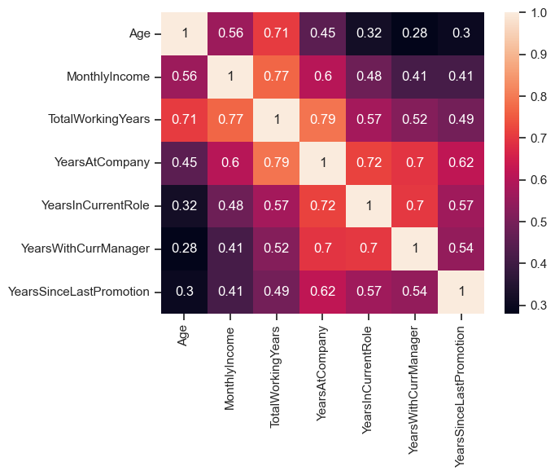

```python
attr_select = attr_metrices[['Age','MonthlyIncome','TotalWorkingYears','YearsAtCompany','YearsInCurrentRole','YearsWithCurrManager','YearsSinceLastPromotion']]

corr_matrix = attr_select.corr()

corr_matrix

sns.heatmap(corr_matrix, annot=True)
plt.show()
```

### Check Linear Relationship between Features

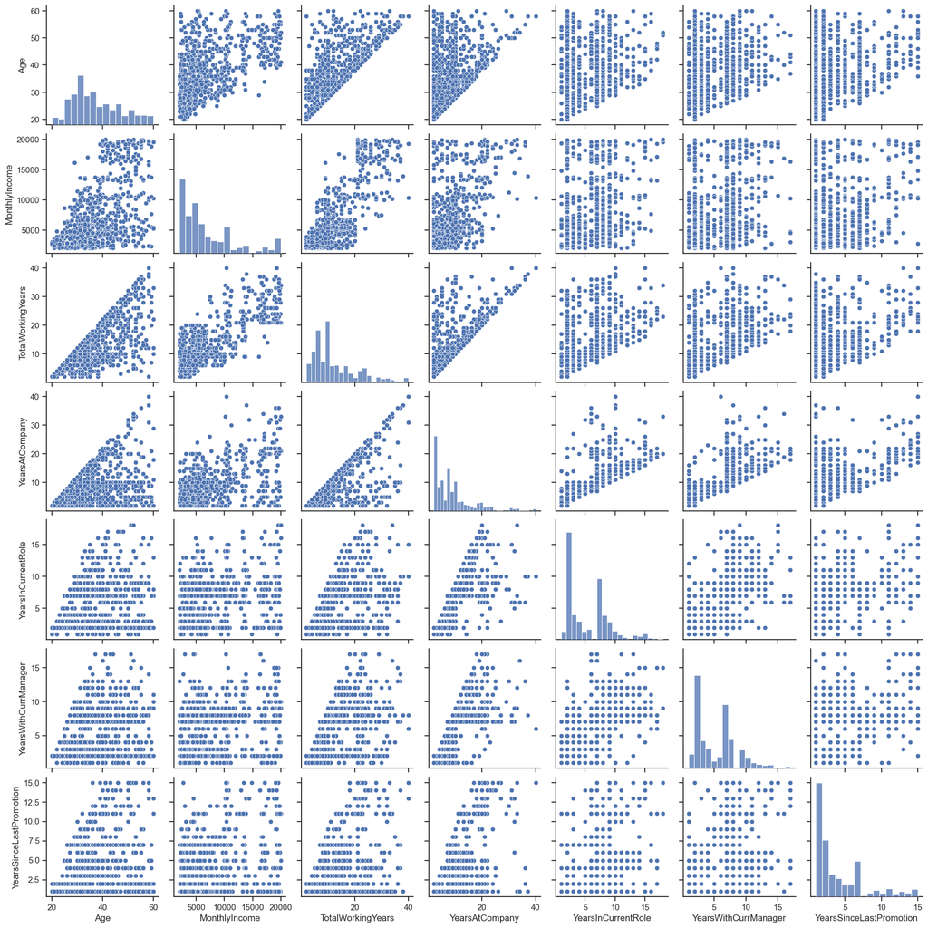

```python
import seaborn as sns
sns.set_theme(style="ticks")

sns.pairplot(attr_select)
```

### Check Outliers between Features

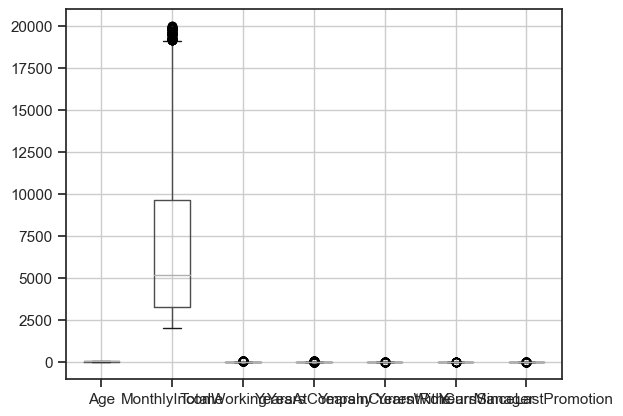

```python
attr_select.boxplot()
```

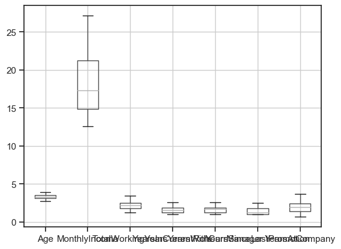

```python
attr_cbrt = np.cbrt(attr_select[['Age','MonthlyIncome','TotalWorkingYears','YearsInCurrentRole','YearsWithCurrManager','YearsSinceLastPromotion']])
attr_cbrt['YearsAtCompany'] = np.log(attr_select['YearsAtCompany'])

#attr_log.hist(figsize=(15,10))
#attr_log.head()

#attr_cbrt.hist(figsize=(15,10))

attr_cbrt.boxplot()

attr_cbrt_norm = attr_cbrt
#attr_cbrt_norm = attr_cbrt_norm[['age','balance','duration']]

#shapiro(attr_cbrt_norm)
#kstest(attr_log_norm.duration, 'norm')
```

After transformation, there were no outlier in the dataset

```python
attr_cbrt_norm.describe()
```

|  | Age | MonthlyIncome | TotalWorkingYears | YearsInCurrentRole | YearsWithCurrManager | YearsSinceLastPromotion | YearsAtCompany |
| --- | --- | --- | --- | --- | --- | --- | --- |
| count | 1404.000000 | 1404.000000 | 1404.000000 | 1404.000000 | 1404.000000 | 1404.000000 | 1404.000000 |
| mean | 3.317025 | 18.182455 | 2.211152 | 1.657536 | 1.657979 | 1.441366 | 1.907887 |
| std | 0.277273 | 4.046636 | 0.489591 | 0.386253 | 0.377399 | 0.450350 | 0.776990 |
| min | 2.714418 | 12.613892 | 1.259921 | 1.000000 | 1.000000 | 1.000000 | 0.693147 |
| 25% | 3.107233 | 14.880156 | 1.817121 | 1.259921 | 1.259921 | 1.000000 | 1.386294 |
| 50% | 3.271066 | 17.333107 | 2.154435 | 1.587401 | 1.709976 | 1.259921 | 1.945910 |
| 75% | 3.530348 | 21.267183 | 2.519842 | 1.912931 | 1.912931 | 1.817121 | 2.397895 |
| max | 3.914868 | 27.143724 | 3.419952 | 2.620741 | 2.571282 | 2.466212 | 3.688879 |

### Standardised the Features

```python
features = attr_cbrt_norm.columns
#features = attr_metrices.columns

features
#attr_log_norm.loc
```

```
Index(['Age', 'MonthlyIncome', 'TotalWorkingYears', 'YearsInCurrentRole',
       'YearsWithCurrManager', 'YearsSinceLastPromotion', 'YearsAtCompany'],
      dtype='object')
```

```python
from sklearn.preprocessing import StandardScaler
from sklearn.preprocessing import MinMaxScaler

x = attr_cbrt_norm.loc[:, features].values
#x = attr_metrices.loc[:, features].values
#x = StandardScaler().fit_transform(x)
x = MinMaxScaler().fit_transform(x)
x.shape
```

```
(1404, 7)
```

```python
np.mean(x), np.std(x)
```

```
(0.40808315966698633, 0.2618955030723899)
```

```python
feat_cols = ['feature'+str(i) for i in range(x.shape[1])]
attr_std = pd.DataFrame(x, columns=feat_cols)

attr_std.head()
```

|  | feature0 | feature1 | feature2 | feature3 | feature4 | feature5 | feature6 |
| --- | --- | --- | --- | --- | --- | --- | --- |
| 0 | 0.355669 | 0.273065 | 0.151609 | 0.160372 | 0.165420 | 0.177274 | 0.000000 |
| 1 | 0.410777 | 0.167575 | 0.342624 | 0.272869 | 0.281458 | 0.000000 | 0.231378 |
| 2 | 0.848093 | 0.533459 | 0.414121 | 0.563280 | 0.581011 | 0.622646 | 0.462756 |
| 3 | 0.925857 | 0.045449 | 0.532502 | 0.666413 | 0.636423 | 0.736649 | 0.537244 |
| 4 | 0.539429 | 0.297247 | 0.302315 | 0.160372 | 0.373836 | 0.000000 | 0.305865 |

At the end, since all variables since beginning doesn't contain NA, therefore the final assumption that the data doesn't contain NA were fulfilled

### Implement PCA

```python
from sklearn.decomposition import PCA
attr_pca = PCA(n_components=3)
attr_pca_tf = attr_pca.fit_transform(x)
```

```python
attr_pca_df = pd.DataFrame(data=attr_pca_tf, columns=['principal_component_1', 'principal_component_2','principal_component_3'])

attr_pca_df.tail()
```

|  | principal_component_1 | principal_component_2 | principal_component_3 |
| --- | --- | --- | --- |
| 1399 | -0.625447 | 0.067115 | -0.002539 |
| 1400 | 0.715885 | -0.067733 | -0.114177 |
| 1401 | -0.002007 | 0.136260 | 0.310557 |
| 1402 | 0.077490 | 0.203992 | 0.304964 |
| 1403 | -0.478864 | 0.115001 | 0.051260 |

Let's find the explained variance ratio which provide the amount of information each principal component holds

```python
print('Explained variation per principal component: {}'.format(attr_pca.explained_variance_ratio_))
```

```
Explained variation per principal component: [0.6195093  0.15217074 0.0946217 ]
```

Here, principal component 1 holds 62%, principal component 2 holds 15.2%, and principal component 3 holds 9.4% of the information, therefore in total, the 3 PCA feature contain 86.6% information of preprocessing data.

```python
attr_cat.Attrition.unique()
```

```
array(['Yes', 'No'], dtype=object)
```

```python
attr_pca_df.shape
```

```
(1404, 3)
```

```python
attr_cat['index'] = np.arange(len(attr_cat))

attr_cat.tail()
```

|  | Attrition | BusinessTravel | Department | Education | EducationField | EmployeeCount | EmployeeNumber | EnvironmentSatisfaction | Gender | JobLevel | JobRole | JobSatisfaction | MaritalStatus | Over18 | OverTime | PerformanceRating | StandardHours | WorkLifeBalance | index |
| --- | --- | --- | --- | --- | --- | --- | --- | --- | --- | --- | --- | --- | --- | --- | --- | --- | --- | --- | --- |
| 1458 | No | Travel_Rarely | Research & Development | 4 | Life Sciences | 1 | 2052 | 3 | Female | 1 | Research Scientist | 4 | Married | Y | No | 3 | 80 | 3 | 1399 |
| 1462 | No | Travel_Rarely | Sales | 1 | Marketing | 1 | 2056 | 2 | Female | 4 | Sales Executive | 4 | Married | Y | No | 3 | 80 | 2 | 1400 |
| 1463 | No | Non-Travel | Research & Development | 3 | Medical | 1 | 2057 | 2 | Male | 2 | Manufacturing Director | 1 | Single | Y | No | 3 | 80 | 3 | 1401 |
| 1466 | No | Travel_Rarely | Research & Development | 1 | Medical | 1 | 2062 | 4 | Male | 3 | Healthcare Representative | 1 | Married | Y | No | 3 | 80 | 3 | 1402 |
| 1469 | No | Travel_Rarely | Research & Development | 3 | Medical | 1 | 2068 | 2 | Male | 2 | Laboratory Technician | 3 | Married | Y | No | 3 | 80 | 4 | 1403 |

```python
attr_pca_df['index'] = np.arange(len(attr_pca_df))
attr_pca_df.tail()
```

|  | principal_component_1 | principal_component_2 | principal_component_3 | index |
| --- | --- | --- | --- | --- |
| 1399 | -0.625447 | 0.067115 | -0.002539 | 1399 |
| 1400 | 0.715885 | -0.067733 | -0.114177 | 1400 |
| 1401 | -0.002007 | 0.136260 | 0.310557 | 1401 |
| 1402 | 0.077490 | 0.203992 | 0.304964 | 1402 |
| 1403 | -0.478864 | 0.115001 | 0.051260 | 1403 |

```python
attr_pca_df = attr_pca_df.merge(attr_cat, left_on="index",right_on="index")

attr_pca_df.drop(['index','BusinessTravel','Department','Education','EducationField','EmployeeCount','EmployeeNumber','EnvironmentSatisfaction','Gender','JobLevel','JobRole','JobSatisfaction','MaritalStatus','Over18','OverTime','PerformanceRating','StandardHours','WorkLifeBalance'],
                axis=1, inplace=True)

attr_pca_df.head()
```

|  | principal_component_1 | principal_component_2 | principal_component_3 | Attrition |
| --- | --- | --- | --- | --- |
| 0 | -0.599901 | 0.019303 | -0.190409 | Yes |
| 1 | -0.448894 | 0.047856 | 0.110873 | Yes |
| 2 | 0.419968 | 0.003926 | -0.202738 | Yes |
| 3 | 0.431378 | -0.280263 | -0.169070 | Yes |
| 4 | -0.354262 | 0.155231 | 0.087164 | Yes |

```python
import plotly.express as px

fig = px.scatter_3d(attr_pca_tf, x=0, y=1,z=2, color=attr_pca_df['Attrition'])
fig.show()
```

[output not shown]

```python
attr_pca_df['Attrition'].value_counts()
```

```
Yes    702
No     702
Name: Attrition, dtype: int64
```

Weirdly, after fulfill all the PCA assumptions, the data still overlapping thus doesn't separate the class well

```
array([[<AxesSubplot:title={'center':'principal_component_1'}>,
        <AxesSubplot:title={'center':'principal_component_2'}>],
       [<AxesSubplot:title={'center':'principal_component_3'}>,
        <AxesSubplot:>]], dtype=object)
```

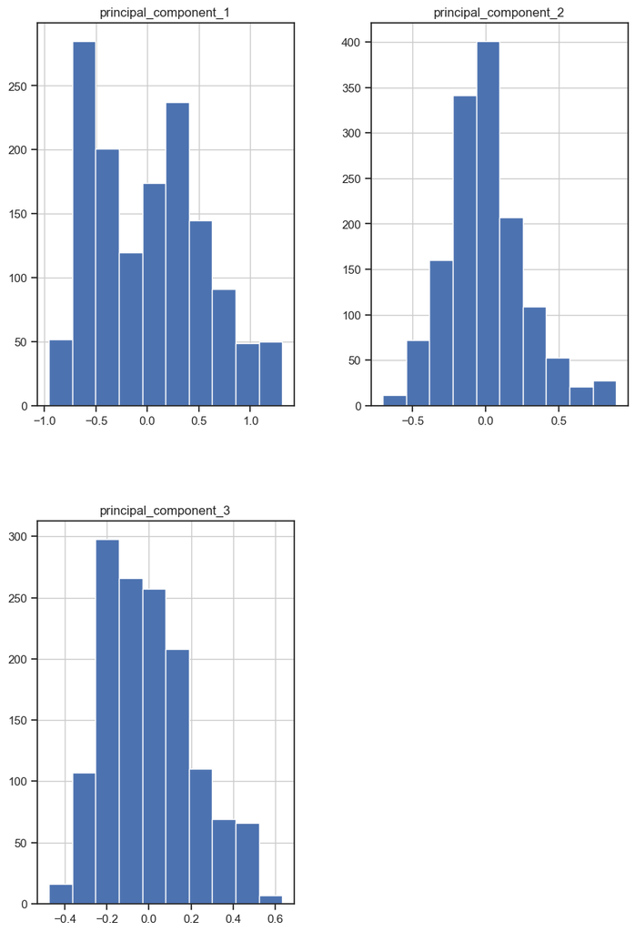

```python
attr_pca_df.hist(figsize=(10,15))
```

```python
attr_pca_df.describe()
```

|  | principal_component_1 | principal_component_2 | principal_component_3 |
| --- | --- | --- | --- |
| count | 1.404000e+03 | 1.404000e+03 | 1.404000e+03 |
| mean | 1.458947e-17 | 1.560757e-17 | -5.184401e-18 |
| std | 5.328926e-01 | 2.641079e-01 | 2.082625e-01 |
| min | -9.581399e-01 | -7.033097e-01 | -4.761144e-01 |
| 25% | -4.965179e-01 | -1.619056e-01 | -1.638193e-01 |
| 50% | -1.078947e-02 | -2.490430e-02 | -1.826265e-02 |
| 75% | 3.844390e-01 | 1.453650e-01 | 1.297978e-01 |
| max | 1.309862e+00 | 8.959132e-01 | 6.340742e-01 |

```python
from scipy.stats import shapiro

shapiro(attr_pca_df[['principal_component_1','principal_component_2','principal_component_3']])
#kstest(attr_pca_df.principal_component_1, "norm")
#kstest(attr_pca_df.principal_component_2, "norm")
#kstest(attr_pca_df.principal_component_3, "norm")
```

```
ShapiroResult(statistic=0.980205774307251, pvalue=8.219583533604646e-24)
```

```python
attr_pca_df["Attrition"] = attr_pca_df['Attrition'].replace(['Yes'],1)
attr_pca_df["Attrition"] = attr_pca_df['Attrition'].replace(['No'],0)

attr_pca_df.Attrition.unique
```

```
<bound method Series.unique of 0       1
1       1
2       1
3       1
4       1
       ..
1399    0
1400    0
1401    0
1402    0
1403    0
Name: Attrition, Length: 1404, dtype: int64>
```

## Classification Applied

Here, let's try to create classification model with logistic regression

### Logistic Regression Assumptions

1. Logistic regression generally works as a classifier, so the type of logistic regression utilized (binary, multinomial, or ordinal) must match the outcome (dependent) variable in the dataset.
2. The relationship between the logit (aka log-odds) of the outcome and each continuous independent variable is linear.
3. Logistic regression assumes that there are no highly influential outlier data points, as they distort the outcome and accuracy of the model.
4. Multicollinearity corresponds to a situation where the data contain highly correlated independent variables. This is a problem because it reduces the precision of the estimated coefficients, which weakens the statistical power of the logistic regression model.
5. The observations must be independent of each other, i.e., they should not come from repeated or paired data. This means that each observation is not influenced by or related to the rest of the observations.
6. There should be an adequate number of observations for each independent variable in the dataset to avoid creating an overfit model.

Source = https://towardsdatascience.com/assumptions-of-logistic-regression-clearly-explained-44d85a22b290

#### 1. Logistic Regression Must Match the Outcome

Since here the dependent variable were consist of Yes and No, we use binary classification

#### 2. The Relationship between Logit of the Outcome and Continous Independent Variables were Linear

```python
#attr_pca_df_tf = attr_pca_df[['principal_component_1','principal_component_2']]

#features = attr_pca_df_tf.columns
#features = attr_metrices.columns

#features
#attr_log_norm.loc

#x = attr_pca_df_tf.loc[:, features].values
#x = attr_metrices.loc[:, features].values
#x = StandardScaler().fit_transform(x)
#x = MinMaxScaler().fit_transform(x)
#x.shape

#np.mean(x), np.std(x)

#feat_cols = ['feature'+str(i) for i in range(x.shape[1])]
#attr_pca_df_tf = pd.DataFrame(x, columns=feat_cols)

#attr_pca_df_tf['Attrition']=attr_pca_df["Attrition"]

#attr_pca_df_tf.head()
```

```python
#attr_pca_df_tf['Attrition']=attr_pca_df["Attrition"]
```

```python
#attr_pca_df_tf.isna().any()
```

```python
#import statsmodels.api as sm
#from statsmodels.genmod.generalized_linear_model import GLM
#from statsmodels.genmod import families

#continous_var = ['feature0', 'feature1']

#for var in continous_var:
#    attr_pca_df_tf[f'{var}:Log_{var}'] = attr_pca_df_tf[var].apply(lambda x: x*np.log(x))

#cols_to_keep = continous_var + attr_pca_df_tf.columns.tolist()[-len(continous_var):]

#X_lt = attr_pca_df_tf[cols_to_keep]

#X_lt_constant = sm.add_constant(X_lt, prepend=False)

#y_lt = attr_pca_df_tf['Attrition']

#logit_results = GLM(y_lt, X_lt_constant, family = families.Binomial()).fit()

#print(logit_results.summary())
```

Here, I can't prove the second assumption since the data contain values <= 0, therefore I can't prove the assumption

#### 3. Inspect Outliers

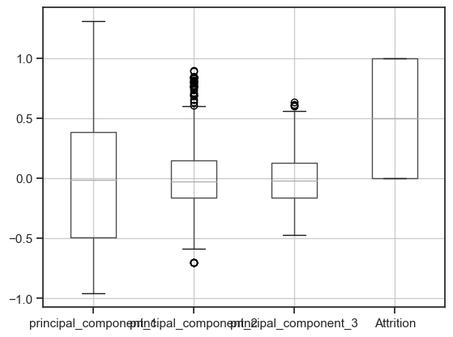

```python
attr_pca_df.boxplot()
```

Here, we see principal_component_2 and principal_component_3 has some upper outlier, but since I dont want to reduce the variance information contained in the data and transforming the data further since I have done it before, lets assumed that this assumption were fulfilled

#### 4. Inspect Multicolienarity from Independent Variable Correlation

```python
attr_pca_df.corr()
```

|  | principal_component_1 | principal_component_2 | principal_component_3 | Attrition |
| --- | --- | --- | --- | --- |
| principal_component_1 | 1.000000e+00 | -9.881589e-17 | 8.444829e-18 | -0.078656 |
| principal_component_2 | -9.881589e-17 | 1.000000e+00 | -2.233417e-16 | -0.114940 |
| principal_component_3 | 8.444829e-18 | -2.233417e-16 | 1.000000e+00 | -0.125579 |
| Attrition | -7.865562e-02 | -1.149400e-01 | -1.255795e-01 | 1.000000 |

After looking at the correlation score, there were no correlation between principal_component_1, principal_component_2, principal_component_3 with very small correlation value approaching 0.

#### 6. Adequate Number of Observation

```python
# Getting total number of raw dataset
print(len(attr_raw))

# Getting total number of observations
print(len(attr_pca_df))
```

```
806
1404
```

Since in the beginning, I already tackle the imbalance class problem with upsampling, the class were already balanced and thus provide sufficient amount.

```python
X = attr_pca_df[['principal_component_1','principal_component_2','principal_component_3']]
y = attr_pca_df['Attrition']
```

```python
from sklearn.model_selection import train_test_split
X_train, X_test, y_train, y_test = train_test_split(X,y, test_size=0.25,random_state=123)
```

```python
ss_train = StandardScaler()
X_train = ss_train.fit_transform(X_train)

ss_test = StandardScaler()
X_test = ss_test.fit_transform(X_test)
```

```python
import sklearn as sk
from sklearn.linear_model import LogisticRegression

model = LogisticRegression(random_state=123, solver='lbfgs', multi_class='ovr').fit(X_train, y_train)

predictions = model.predict(X_test)
```

```python
from sklearn.metrics import confusion_matrix

cm = confusion_matrix(y_test, predictions)

TN, FP, FN, TP = confusion_matrix(y_test, predictions).ravel()

print("True Positive(TP) = ", TP)
print("False Positive(FP) = ", FP)
print("True Negative(TN) = ", TN)
print("False Negative = ",FN)

accuracy = (TP+TN)/(TP+FP+TN+FN)

print("Accuracy :{:0.3f}".format(accuracy) )
```

```
True Positive(TP) =  112
False Positive(FP) =  85
True Negative(TN) =  93
False Negative =  61
Accuracy :0.584
```

From the Logistic Regression algorithm, the accuracy were quite low

## Binary Classification Loop

```python
models = {}

# Logistic Regression
from sklearn.linear_model import LogisticRegression
models['Logistic Regression'] = LogisticRegression()

# Support Vector Machines
from sklearn.svm import LinearSVC
models['Support Vector Machines'] = LinearSVC()

# Decision Trees
from sklearn.tree import DecisionTreeClassifier
models['Decision Trees'] = DecisionTreeClassifier()

# Random Forest
from sklearn.ensemble import RandomForestClassifier
models['Random Forest'] = RandomForestClassifier()

# Naive Bayes
from sklearn.naive_bayes import GaussianNB
models['Naive Bayes'] = GaussianNB()

# K-Nearest Neighbors
from sklearn.neighbors import KNeighborsClassifier
models['K-Nearest Neighbor'] = KNeighborsClassifier()
```

```python
from sklearn.metrics import accuracy_score, precision_score, recall_score

accuracy, precision, recall = {}, {}, {}

for key in models.keys():

    # Fit the classifier
    models[key].fit(X_train, y_train)

    # Make predictions
    predictions = models[key].predict(X_test)

    # Calculate metrics
    accuracy[key] = accuracy_score(predictions, y_test)
    precision[key] = precision_score(predictions, y_test)
    recall[key] = recall_score(predictions, y_test)
```

```python
df_model = pd.DataFrame(index=models.keys(), columns=['Accuracy', 'Precision', 'Recall'])
df_model['Accuracy'] = accuracy.values()
df_model['Precision'] = precision.values()
df_model['Recall'] = recall.values()

df_model
```

|  | Accuracy | Precision | Recall |
| --- | --- | --- | --- |
| Logistic Regression | 0.584046 | 0.647399 | 0.568528 |
| Support Vector Machines | 0.581197 | 0.647399 | 0.565657 |
| Decision Trees | 0.712251 | 0.595376 | 0.768657 |
| Random Forest | 0.726496 | 0.560694 | 0.829060 |
| Naive Bayes | 0.586895 | 0.716763 | 0.563636 |
| K-Nearest Neighbor | 0.698006 | 0.780347 | 0.665025 |

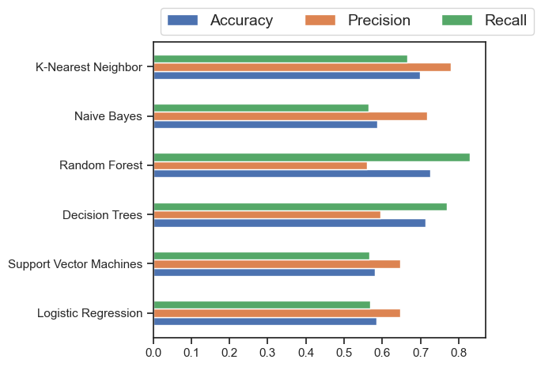

```python
ax = df_model.plot.barh()
ax.legend(
    ncol=len(models.keys()),
    bbox_to_anchor=(0, 1),
    loc='lower left',
    prop={'size': 14}
)
plt.tight_layout()
```

With iterating the model implemented with input dataset, it may be more appropriate too look at accuracy and recall, the accuracy shows how many observation our model correctly predicted. The second one is recall, this is because I assumed that as an HR, we wouldn't want to miss any employee that may be resign and also having less concern if the employee actually doesn't planning to quit.

Random forest also has no formal distribution assumption, can handle skewed data, multi-modal data, as well as categorical data such as ordinal and non-ordinal data. Since the assumption were fulfilled with the curent training dataset, later I can further honed the Random Forest by parameter tuning it.